# Danishuni mejorado

Arturo Sánchez Palacio

En primer lugar se cargan las bibliotecas que vamos a emplear:

```r
library(moments)
library(actuar)
library(fitdistrplus)
library(ggplot2)
library(MASS)
library(CASdatasets)
library(car)
library(dplyr)
library(lubridate)
library(OpVaR)
library(QRM)
```

# Carga de datos

Tras esto se procede a la carga y al agrupamiento de datos y se comprueba que se han cargado de manera correcta:

```r
datos_agregados <- danishuni %>% group_by(semanas = floor_date(danishuni$Date, "week")) %>% summarize(siniestros = n(), Loss = sum(Loss))
```

Una vez hecho esto se procede al análisis exploratorio.

# Análisis exploratorio

Se plantea una primera aproximación a los datos:

```r
summary(datos_agregados)
```

```
    semanas             siniestros          Loss
 Min.   :1979-12-30   Min.   : 1.000   Min.   :  1.004
 1st Qu.:1982-09-17   1st Qu.: 2.000   1st Qu.:  5.143
 Median :1985-07-17   Median : 4.000   Median :  8.495
 Mean   :1985-07-04   Mean   : 3.926   Mean   : 13.289
 3rd Qu.:1988-04-04   3rd Qu.: 5.000   3rd Qu.: 15.618
 Max.   :1990-12-30   Max.   :13.000   Max.   :264.700
```

La columna siniestros muestra la frecuencia con la que se producen las pérdidas (agrupada por semanas) y la columna Loss su severidad (de nuevo agregada por semanas)

## Análisis frecuencia

Para las frecuencias que son valores discretos se puede plantear una tabla:

```r
table(datos_agregados$siniestros)
```

```
  1   2   3   4   5   6   7   8   9  10  11  12  13
 57  96 103 126  63  36  32  17  13   5   2   1   1
```

```r
length(datos_agregados$siniestros)
```

```
[1] 552
```

```r
sum(datos_agregados$siniestros)
```

```
[1] 2167
```

Se produce un total de 2167 pérdidas repartidas a lo largo de 552 semanas.

Se calcula el coeficiente de asimetría:

```r
skewness(datos_agregados$siniestros)
```

```
[1] 0.946363
attr(,"method")
[1] "moment"
```

Como es positivo la asimetría es positiva, es decir,los valores se concentran a la izquierda.

Se calcula la curtosis:

```r
kurtosis(datos_agregados$siniestros)
```

```
[1] 0.9512255
attr(,"method")
[1] "excess"
```

Se calculan cuantiles:

```r
quantile(datos_agregados$siniestros,seq(0,1, 0.20))
```

```
  0%  20%  40%  60%  80% 100%
   1    2    3    4    5   13
```

```r
quantile(datos_agregados$siniestros, seq(0.9,1, 0.01))
```

```
  90%   91%   92%   93%   94%   95%   96%   97%   98%   99%  100%
 7.00  7.00  7.00  7.43  8.00  8.00  8.00  9.00  9.00 10.00 13.00
```

Por último se presenta el histograma de la distribución de frecuencia:

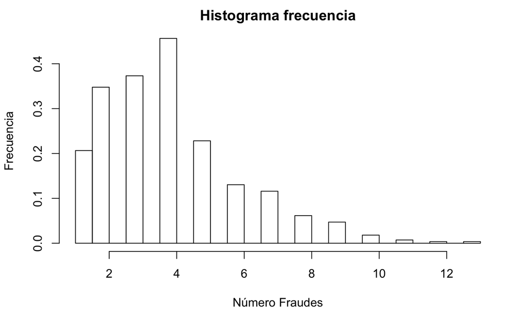

```r
hist(datos_agregados$siniestros, pch = 20, breaks = 25, prob = TRUE, main = "Histograma frecuencia",
     xlab = "Número Fraudes", ylab = "Frecuencia")
```

Se realizaría un razonamiento análogo para la severidad.

# Ajustes de frecuencia y severidad

## Ajuste de frecuencia

Empleamos un ajuste de máxima verosimilitud para la frecuencia:

```r
(fpois <- fitdist(datos_agregados$siniestros, "pois"))
```

```
NaNs producedNaNs produced
```

```
Fitting of the distribution ' pois ' by maximum likelihood
Parameters:
```

|  | estimate | Std. Error |
| --- | --- | --- |
| lambda | 3.925725 | 0.0843316 |

Ajusta a la milésima y el error es bastante bajo así que parece un buen ajuste.

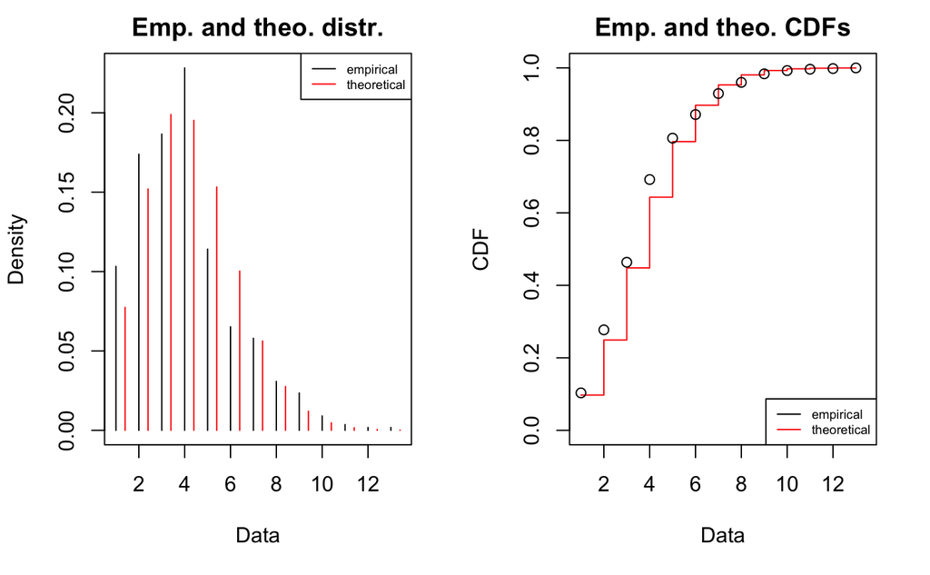

```r
plot(fpois)
```

```r
(fnbinom <- fitdist(datos_agregados$siniestros, "nbinom"))
```

```
NaNs producedNaNs produced
```

```
Fitting of the distribution ' nbinom ' by maximum likelihood
Parameters:
```

|  | estimate | Std. Error |
| --- | --- | --- |
| size | 27.697913 | 12.92097342 |
| mu | 3.925621 | 0.09010726 |

El error es mayor y la distribución más compleja por lo que se preferiría la Poisson (el parámetro size se ignora).

```r
gofstat(list(fpois, fnbinom), chisqbreaks=c(0:4, 9), discrete=TRUE,
        fitnames=c("Poisson", "Binomial Negativa"))
```

```
Chi-squared statistic:  32.53147 28.71295
Degree of freedom of the Chi-squared distribution:  5 4
Chi-squared p-value:  4.661851e-06 8.940322e-06
   the p-value may be wrong with some theoretical counts < 5
Chi-squared table:
     obscounts theo Poisson theo Binomial Negativa
<= 0         0    10.889765              14.046057
<= 1        57    42.750220              48.294693
<= 2        96    83.912797              86.023608
<= 3       103   109.806179             105.711019
<= 4       126   107.767206             100.708713
<= 9       161   192.902628             190.655306
> 9          9     3.971205               6.560603

Goodness-of-fit criteria
                                Poisson Binomial Negativa
Akaike's Information Criterion 2334.167          2330.564
Bayesian Information Criterion 2338.480          2339.191
```